# Final Project - Exhaustive Document

Alexander Karr

2024-04-01

*The goal of this week’s homework is to complete the alignment and read count generation of all the samples of your project data. You all had a first go at it during the HW of week 6. Now is the time to get back to that, change what needs to be changed and write a script that will perform the alignment for all your samples. The final step for this week should generate a table of read counts which you should read into R.*

*Set up a github repository where you will store all your scripts, and your final report. Submit the URL of your repo. If you want to set it to private, you will have to grant us access, i.e., Luce (lskrbnek), Merv (mfansler), Cyrus (tamlongyat). Align all your samples. Ideally use a for-loop within a script, i.e., automate and standardize the task to a certain extent, but do remember that legibility is valuable, too.*

*Generate a read count table:*

*Load the read count table into R and perform the quality controls and processing steps that we discussed in class. We also strongly encourage you to start reading up on the biological background of your samples so that you can put the results of the QC and explorations into their context. Always try to answer the question “Does this make sense?!” when generating a new plot.*

# Part 1 - Sample Alignment

## Downloading and processing remaining samples

I prefetch my last two remaining fastq files of my BJ48h condition (pre-Yamanaka induction). The samples themselves are titled BJ48hS2 and BJ48hS3, respectively. I then download my three samples of my post-Yamanaka-factor-induction condition BJOSKM96hS1, BJOSKM96hS2, and BJOSKM96hS3.

```bash
prefetch SRX9283432
prefetch SRX9283433
prefetch SRX9283443
prefetch SRX9283444
prefetch SRX9283445
```

I then use fasterq dump with the paired end option.

```bash
fasterq-dump --split-files SRR12815321/
Output:
spots read      : 57,203,398
reads read      : 114,406,796
reads written   : 57,203,398
reads 0-length  : 57,203,398
```

```bash
fasterq-dump --split-files SRR12815322/
Output:
spots read      : 61,690,860
reads read      : 123,381,720
reads written   : 61,690,860
reads 0-length  : 61,690,860
```

```bash
fasterq-dump --split-files SRR12815332/
```

```bash
fasterq-dump --split-files SRR12815333/
```

```bash
fasterq-dump --split-files SRR12815334/
```

I wrote a shell script to gzip all of my remaining fastq files. I do this in scratch, and then move them using VS code to my project folder.

```bash
#!/bin/bash

#SBATCH --partition=angsd_class
#SBATCH --nodes=1
#SBATCH --cpus-per-task=8
#SBATCH --job-name=gzipFastqs
#SBATCH --time=01:0:00  # Adjust based on your expectation of job runtime
#SBATCH --mem=20G        # Adjust based on your expectation of memory need

# Check if at least one argument is provided
if [ $# -eq 0 ]; then
    echo "No fastq files provided!"
    exit 1
fi

# Loop through each fastq file and gzip it
for file in "$@"; do
    gzip "$file"
done
```

```bash
I run the gzipping script after making it executable.
chmod +x gzip_fastqs.sh
sbatch gzip_fastqs.sh SRR12815321_1.fastq SRR12815321_2.fastq SRR12815322_1.fastq SRR12815322_2.fastq SRR12815332_1.fastq SRR12815332_2.fastq SRR12815333_1.fastq SRR12815333_2.fastq SRR12815333_2.fastq SRR12815334_2.fastq
```

## FastQC

I then run FastQC, and aggregate all of this into a MultiQC report on all of my samples. I test for BGI-specific adapter sequences. The study authors stated that “the fastq sequences did not require adapter removal, trimming, or filtering” in the methods of their Nature paper. But I want to verify that statement myself, and thus found custom adapter sequences online that were recommended for testing with BGI (rather than Illumina). I place them in a text file called custom_adapters.txt. The contents are below (I would like you guys to see, in case I got these sequences wrong. I struggled to find any information online).

> AAGTCGGAGGCCAAGCGGTCTTAGGAAGACAA AAGTCGGAGGCCAAGCGGTCTTAGGAAGACAA AAGTCGGATCGTAGCCATGTCGTTCTGTGAGCCAAGGAGTTG AAGTCGGATCGTAGCCATGTCGTTCTGTGAGCCAAGGAGTTG

I also rename all of the FastQC files to their actual sample names. My script for FastQC and MultiQC is below:

```bash
#!/bin/bash -l

#SBATCH --partition=angsd_class
#SBATCH --nodes=1
#SBATCH --cpus-per-task=8
#SBATCH --job-name=fastAndMultiQC
#SBATCH --time=01:00:00  # Adjust based on your expectation of job runtime
#SBATCH --mem=10G        # Adjust based on your expectation of memory need

# Load the FastQC and MultiQC modules
mamba activate angsd

# Define the directory to store the FastQC and MultiQC output
OUTPUT_DIR="qc_output"

# Define the file containing the custom adapter sequences
ADAPTERS_FILE="custom_adapters.txt"

# Create the output directory if it doesn't exist
mkdir -p ${OUTPUT_DIR}

# Loop over all FASTQ files provided as arguments
for FASTQ_FILE in "$@"
do
    # Run FastQC on the current FASTQ file
    fastqc ${FASTQ_FILE} --outdir ${OUTPUT_DIR} --contaminants ${ADAPTERS_FILE}

    # Copy the FastQC report to the output directory
    cp ${FASTQ_FILE}_fastqc.zip ${OUTPUT_DIR}
    cp ${FASTQ_FILE}_fastqc.html ${OUTPUT_DIR}
done

mamba activate multiqc
# Run MultiQC on the FastQC reports in the output directory
multiqc ${OUTPUT_DIR} --outdir ${OUTPUT_DIR}
```

I render executable, and then run this script.

```bash
chmod +x fast_and_multiqc.sh
sbatch fast_and_multiqc.sh BJ48hS1_1.fastq.gz BJ48hS1_2.fastq.gz BJ48hS2_1.fastq.gz BJ48hS2_2.fastq.gz BJ48hS3_1.fastq.gz BJ48hS3_2.fastq.gz BJOSKM96HS1_1.fastq.gz BJOSKM96HS1_2.fastq.gz BJOSKM96HS2_1.fastq.gz BJOSKM96HS2_2.fastq.gz BJOSKM96HS3_1.fastq.gz BJOSKM96HS3_2.fastq.gz
```

I will include my MultiQC report in my github repo (containing my later QoRTs quality control as well). But I wanted to highlight plots of interest, that either stood out to me on their own, or were related to issues that I have already discussed with you guys.

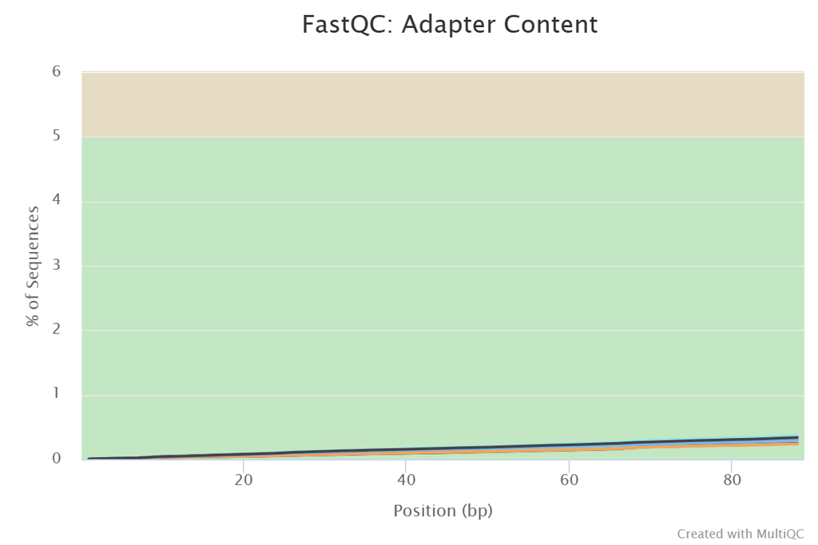

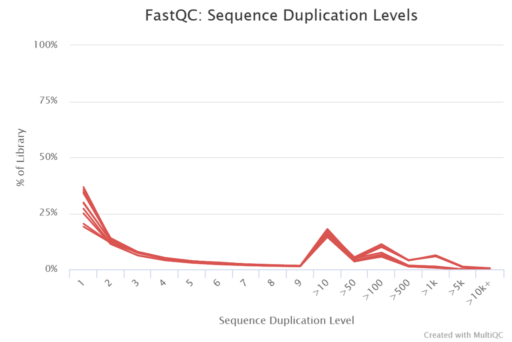

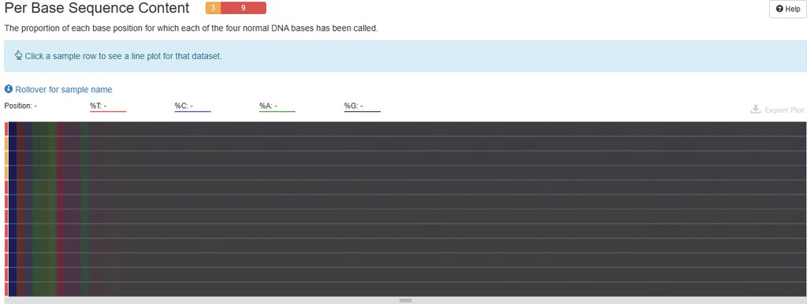

The last standout result in my pre-alignment quality control is the per base sequence content, quantifying the proportion of each base at each position in the 100 BP reads from my samples. By about base pair number 10 (reading from left to right and 5’ to 3’), this base imbalance has disappeared in all samples. Given the use of random hexamers to prime reverse transcription with this library, however, this bias at the 5’ end is common, and as a known technical artifact, does not normally adversely affect downstream analysis as far as I know.

## Running STAR and using SAMtools

I then run my all_samples_alignment.sh shell script on all of my remaining samples, with the same STAR parameters as I did for my first sample. Those will be visible in the script below.

The alignment shell script is below:

```bash
#!/bin/bash -l

#SBATCH --partition=angsd_class
#SBATCH --nodes=1
#SBATCH --cpus-per-task=8
#SBATCH --job-name=allSamplesAlignment
#SBATCH --time=04:00:00  # Adjust based on your expectation of job runtime
#SBATCH --mem=50G        # Adjust based on your expectation of memory need

# Load the STAR module, if necessary. This command might change based on your system's module environment.
# module load STAR

mamba activate angsd

# Define the directory containing the genome index
GENOME_DIR="star_index_output"

# Define the directory to store the alignment output
ALIGNMENT_DIR="star_alignment_output"

# Create an array with all input FASTQ files
FASTQ_FILES=("$@")

# Loop over all pairs of FASTQ files
for ((i=0; i<${#FASTQ_FILES[@]}; i+=2))
do
    # Define paths to the FASTQ files
    FASTQ1=${FASTQ_FILES[$i]}
    FASTQ2=${FASTQ_FILES[$i+1]}

    # Define the output prefix for this pair of FASTQ files
    OUTPUT_PREFIX="${ALIGNMENT_DIR}/$(basename ${FASTQ1} .fastq.gz)_$(basename ${FASTQ2} .fastq.gz)"

    # Run STAR for alignment
    STAR --genomeDir ${GENOME_DIR} \
         --readFilesIn ${FASTQ1} ${FASTQ2} \
         --runThreadN ${SLURM_CPUS_PER_TASK} \
         --outSAMtype BAM SortedByCoordinate \
         --outFileNamePrefix ${OUTPUT_PREFIX} \
         --readFilesCommand zcat  # Use this if your FASTQ files are gzipped
done
```

```bash
cd Project
chmod +x all_samples_alignment.sh
sbatch all_samples_alignment.sh BJ48hS2_1.fastq.gz BJ48hS2_2.fastq.gz BJ48hS3_1.fastq.gz BJ48hS3_2.fastq.gz BJOSKM96HS1_1.fastq.gz BJOSKM96HS1_2.fastq.gz BJOSKM96HS2_1.fastq.gz BJOSKM96HS2_2.fastq.gz BJOSKM96HS3_1.fastq.gz BJOSKM96HS3_2.fastq.gz
```

I begin with this use of samtools to make sure that my alignment file appears to have the right organizational structure by looking at the header from one sample of each condition..

```bash
samtools view -H  star_alignment_output/BJ48hS2_Aligned.sortedByCoord.out.bam | head
output:
@HD     VN:1.4  SO:coordinate
@SQ     SN:chr1 LN:248956422
@SQ     SN:chr2 LN:242193529
@SQ     SN:chr3 LN:198295559
@SQ     SN:chr4 LN:190214555
@SQ     SN:chr5 LN:181538259
@SQ     SN:chr6 LN:170805979
@SQ     SN:chr7 LN:159345973
@SQ     SN:chr8 LN:145138636
@SQ     SN:chr9 LN:138394717
```

```bash
samtools view -H star_alignment_output/BJOSKM96hS1.sortedByCoord.bam | head
Output:
@HD     VN:1.4  SO:coordinate
@SQ     SN:chr1 LN:248956422
@SQ     SN:chr2 LN:242193529
@SQ     SN:chr3 LN:198295559
@SQ     SN:chr4 LN:190214555
@SQ     SN:chr5 LN:181538259
@SQ     SN:chr6 LN:170805979
@SQ     SN:chr7 LN:159345973
@SQ     SN:chr8 LN:145138636
@SQ     SN:chr9 LN:138394717
```

I will then index the remaining alignment files.

```bash
samtools index star_alignment_output/BJ48hS2_Aligned.sortedByCoord.out.bam
samtools index star_alignment_output/BJ48hS3_Aligned.sortedByCoord.out.bam
samtools index star_alignment_output/BJOSKM96HS1.sortedByCoord.bam
samtools index star_alignment_output/BJOSKM96HS2.sortedByCoord.bam
samtools index star_alignment_output/BJOSKM96HS3.sortedByCoord.bam
```

# Part 2 - Alignment QC

After initially attempting to use RseQC in mimicry of the study authors, I eventually resorted to QoRTs given that my GTF appeared incapable of converting to a BED format that could work with RSeQC. From searching online, it seems like Gencode annotations - with how thorough they are, often need to be pre-processed before a successful bedops conversion to .bed format.

## Running and analyzing QoRTs

Below is my script for generating all of my QoRTs post-alignment quality control data/plots.

```bash
#!/bin/bash -l

#SBATCH --partition=angsd_class
#SBATCH --nodes=1
#SBATCH --cpus-per-task=8
#SBATCH --job-name=QoRTsQC
#SBATCH --time=04:00:00  # Adjust based on your expectation of job runtime
#SBATCH --mem=70G        # Adjust based on your expectation of memory need

mamba activate qorts

# Get the GTF file from the arguments
gtf_file="${@: -1}"

# Loop over all other arguments, which should be BAM files
for bam_file in "${@:1:$#-1}"
do
    # Extract the sample name from the BAM file name
    sample_name=$(basename "$bam_file" .bam)

    # Create a directory for the output
    mkdir -p "${sample_name}_qorts_output"

    # Run qorts with fewer options
    qorts -Xmx48G QC \ --generatePlots --title "$sample_name" \
    --addFunctions writeGeneCounts \
    "$bam_file" "$gtf_file" "${sample_name}_qorts_output"
done
```

```bash
chmod +x post_alignment_qc.sh
sbatch post_alignment_qc.sh star_alignment_output/BJ48hS1.sortedByCoord.bam star_alignment_output/BJ48hS2.sortedByCoord.bam star_alignment_output/BJ48hS3.sortedByCoord.bam star_alignment_output/BJOSKM96hS1.sortedByCoord.bam star_alignment_output/BJOSKM96hS2.sortedByCoord.bam star_alignment_output/BJOSKM96hS3.sortedByCoord.bam gencode.v45.primary_assembly.basic.annotation.gtf
```

Although I have already collectively analyzed my FastQC results, running MultiQC on them to see if any of the results would have altered my choice of STAR parameters or made me want to go back and trim adapters, I will include my FastQC results in the final MultiQC report for ease of access.

So, after moving all of my QoRTs and FastQC files into my qc_output directory, I Multiqc them all. The report is output to the directory final_multiqc_dir.

```bash
multiqc qc_output/ -o final_multiqc_dir
```

My full QoRTs multiplot PDFs, as well as my aggregate MultiQC report, will be on my Github repo. For ease of access, however, and to draw particular attention to them, I will include images of some gene-body coverage, gene assignment diversity, and clipping rate plots below.

**BJ48h - Sample One**

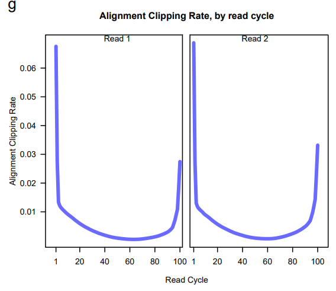

**BJ48h - Sample Two**

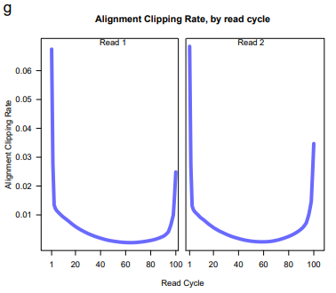

**BJ48h - Sample Three**

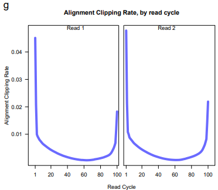

**BJOSKM96h - Sample One**

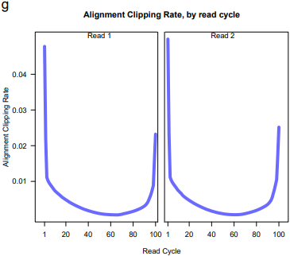

**BJOSKM96h - Sample Two**

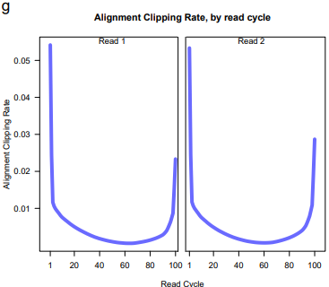

**BJOSKM96h - Sample Three**

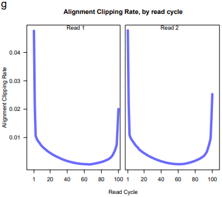

**BJ48h - Sample One**

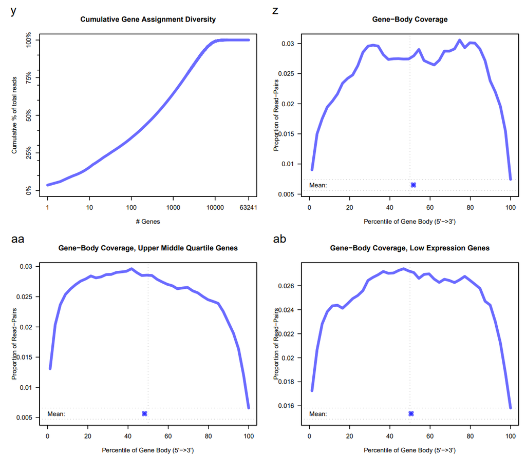

**BJ48h - Sample Two**

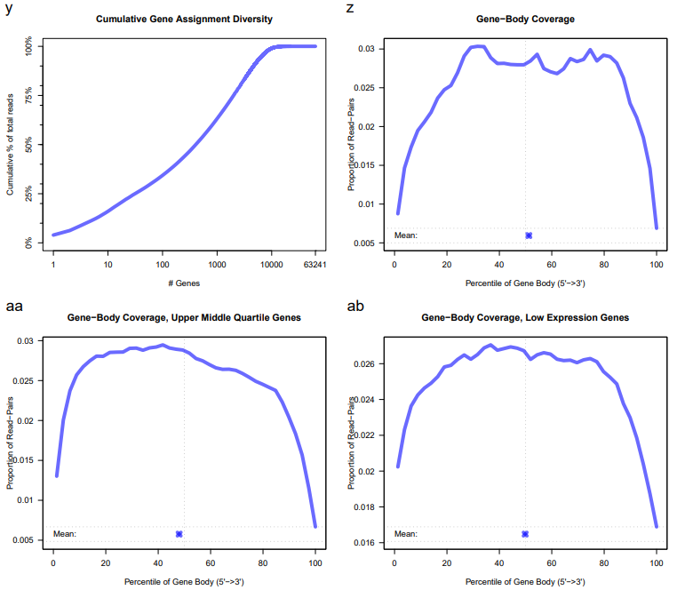

**BJ48h - Sample Three**

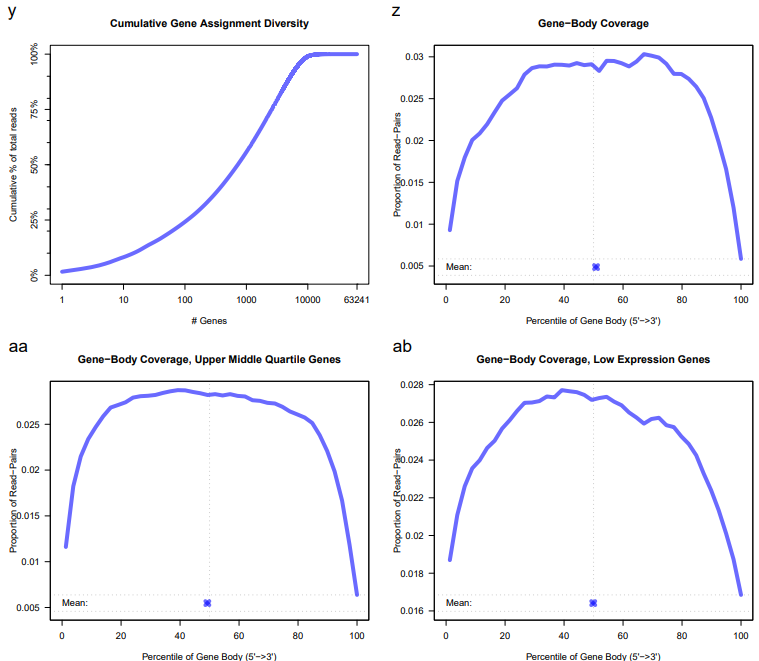

**BJOSKM96h - Sample One**

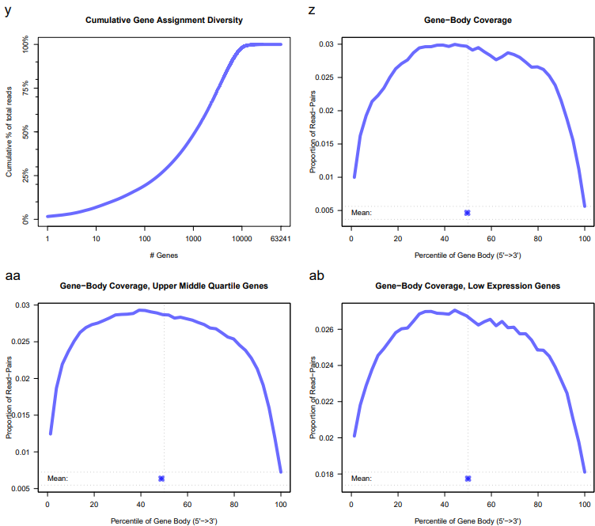

**BJOSKM96h - Sample Two**

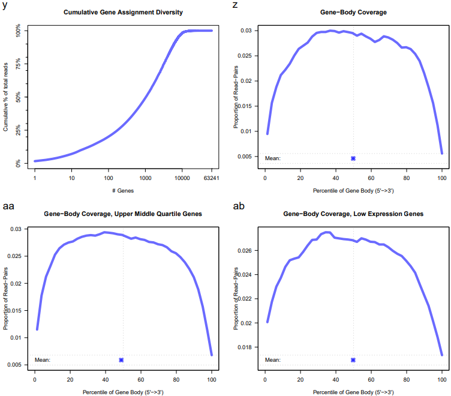

**BJOSKM96h - Sample Three**

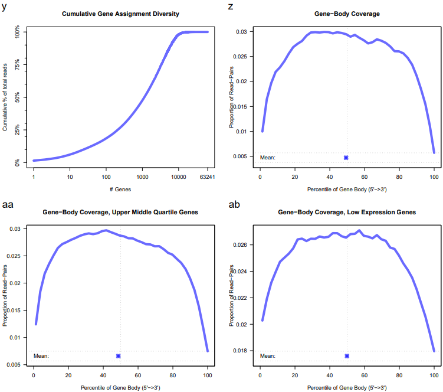

As aforementioned, I will include my MultiQC report and full QoRTs multiplots for all of my samples in my Github repo.

# Part 3 - Read count generation and quality control

## featureCounts

I read a script that performs featureCounts with default parameters (excepting -p and –countReadPairs for paired-end reads) on all of my samples in aggregate. The script is below:

```bash
#!/bin/bash -l

#SBATCH --partition=angsd_class
#SBATCH --nodes=1
#SBATCH --cpus-per-task=8
#SBATCH --job-name=featureCounts
#SBATCH --time=01:00:00  # Adjust based on your expectation of job runtime
#SBATCH --mem=10G        # Adjust based on your expectation of memory need

mamba activate angsd

# Path to your annotation file
annotation_file="${@: -1}"

# Create an array to hold the bam files
declare -a bam_files

# Loop over all other arguments, which should be BAM files
for bam_file in "${@:1:$#-1}"
do
    # Add the bam file to the array
    bam_files+=("$bam_file")
done

# Run featureCounts on all bam files at once
featureCounts -p --countReadPairs -a $annotation_file -o "featureCountsOutput.counts" "${bam_files[@]}"
```

I render the featureCounts script executable and run it, downloading the resulting summary and counts file to my local computer for processing in rstudio.

```bash
chmod +x all_samples_featureCounts.sh
sbatch all_samples_featureCounts.sh star_alignment_output/BJ48hS1.sortedByCoord.bam star_alignment_output/BJ48hS2.sortedByCoord.bam star_alignment_output/BJ48hS3.sortedByCoord.bam star_alignment_output/BJOSKM96hS1.sortedByCoord.bam star_alignment_output/BJOSKM96hS2.sortedByCoord.bam star_alignment_output/BJOSKM96hS3.sortedByCoord.bam gencode.v45.primary_assembly.basic.annotation.gtf
```

```r
count_summary = read.table("finalFeatureCountsOutput.counts.summary")
print(count_summary)
```

```
##                               V1
## 1                         Status
## 2                       Assigned
## 3            Unassigned_Unmapped
## 4           Unassigned_Read_Type
## 5           Unassigned_Singleton
## 6      Unassigned_MappingQuality
## 7             Unassigned_Chimera
## 8      Unassigned_FragmentLength
## 9           Unassigned_Duplicate
## 10       Unassigned_MultiMapping
## 11          Unassigned_Secondary
## 12           Unassigned_NonSplit
## 13         Unassigned_NoFeatures
## 14 Unassigned_Overlapping_Length
```

[output cut: 97 more lines]

## Interpreting the featureCounts summary file

I clean up the sample names in the “Status” row.

```r
# Assuming your data is in a dataframe called 'count_summary' and the sample names are in the first row

# Adjust the regular expression to match both BJ48h and BJOSKM96HS sample names
count_summary[1, -1] <- sapply(count_summary[1, -1], function(x) {
  # Updated regex to capture BJ48hS# and BJOSKM96HS#
  matches <- regmatches(x, regexpr("(BJ48hS\\d+|BJOSKM96hS\\d+)", x))
  return(matches)
})

# Print the cleaned first row to check
print(count_summary[1,])
```

```
##       V1      V2      V3      V4          V5          V6          V7
## 1 Status BJ48hS1 BJ48hS2 BJ48hS3 BJOSKM96hS1 BJOSKM96hS2 BJOSKM96hS3
```

```r
library(tidyr)
library(dplyr)
```

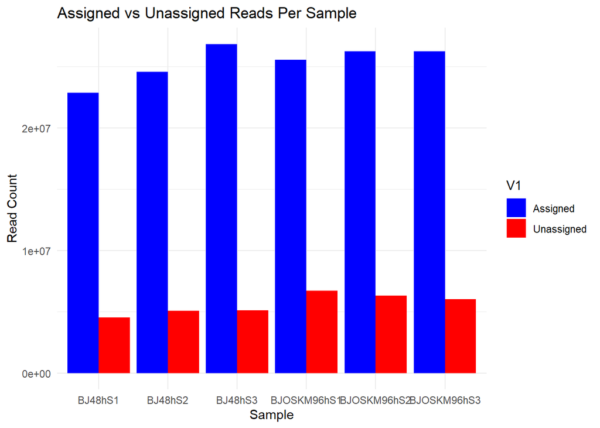

```r
library(ggplot2)
# Convert count values to numeric
count_summary[-1, -1] <- apply(count_summary[-1, -1], 2, as.numeric)

# Reshape data from wide to long format for easier manipulation
count_long <- pivot_longer(count_summary, cols = -V1, names_to = "Sample", values_to = "Count")

# First, ensure all counts are numeric
count_long$Count <- as.numeric(count_long$Count)
# Calculate total unassigned by summing all Unassigned categories
total_unassigned <- count_long %>%
  filter(V1 != "Status", V1 != "Assigned") %>%
  group_by(Sample) %>%
  summarize(Count = sum(Count, na.rm = TRUE)) %>%
  mutate(V1 = "Unassigned")

# Extract assigned reads, ensuring it has the same columns as total_unassigned
assigned_reads <- count_long %>%
  filter(V1 == "Assigned") %>%
  select(Sample, V1, Count)

# Combine Assigned and Total Unassigned reads
combined_reads <- bind_rows(assigned_reads, total_unassigned)

# Define the mapping from "V" labels to "BJ48hS#" labels
sample_name_map <- c(V2 = "BJ48hS1", V3 = "BJ48hS2", V4 = "BJ48hS3", V5 = "BJOSKM96hS1", V6 = "BJOSKM96hS2", V7 = "BJOSKM96hS3")

# Plot Assigned vs Unassigned for each sample with correct names in the x-axis
ggplot(combined_reads, aes(x = factor(Sample, labels = sample_name_map), y = Count, fill = V1)) +
  geom_bar(stat = "identity", position = position_dodge()) +
  scale_fill_manual(values = c("Assigned" = "blue", "Unassigned" = "red")) +
  labs(title = "Assigned vs Unassigned Reads Per Sample", x = "Sample", y = "Read Count") +
  theme_minimal()
```

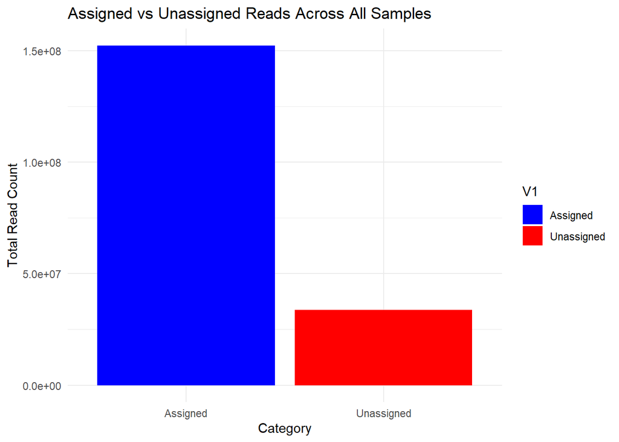

```r
# Calculate total Assigned and Unassigned across all samples
total_combined <- combined_reads %>%
  group_by(V1) %>%
  summarize(Total_Count = sum(Count, na.rm = TRUE)) %>%
  ungroup()

# Plot Assigned vs Unassigned for all samples combined
ggplot(total_combined, aes(x = V1, y = Total_Count, fill = V1)) +
  geom_bar(stat = "identity", position = position_dodge()) +
  scale_fill_manual(values = c("Assigned" = "blue", "Unassigned" = "red")) +
  labs(title = "Assigned vs Unassigned Reads Across All Samples", x = "Category", y = "Total Read Count") +
  theme_minimal()
```

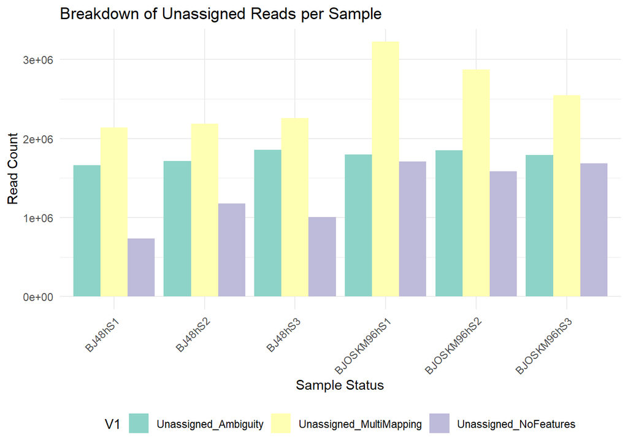

```r
# For the breakdown of Unassigned reads, ensure we exclude zero counts and adjust labels as necessary
unassigned_details <- count_long %>%
  filter(V1 != "Status" & V1 != "Assigned" & Count > 0)


# Plot for different types of Unassigned reads for each sample with correct names in the x-axis
ggplot(unassigned_details, aes(x = factor(Sample, labels = sample_name_map), y = Count, fill = V1)) +
  geom_bar(stat = "identity", position = "dodge") +
  scale_fill_brewer(palette = "Set3") +
  labs(title = "Breakdown of Unassigned Reads per Sample", x = "Sample Status", y = "Read Count") +
  theme_minimal() +
  theme(axis.text.x = element_text(angle = 45, hjust = 1), legend.position = "bottom")
```

## Processing the featureCounts count table.

```r
library(DESeq2)
```

```r
library(ggplot2)
library(magrittr)
count_table = read.table("finalFeatureCountsOutput.counts")
#print(names(count_table))
print(count_table[1, ])
```

```
##       V1  V2    V3  V4     V5     V6
## 1 Geneid Chr Start End Strand Length
##                                                V7
## 1 star_alignment_output/BJ48hS1.sortedByCoord.bam
##                                                V8
## 1 star_alignment_output/BJ48hS2.sortedByCoord.bam
##                                                V9
## 1 star_alignment_output/BJ48hS3.sortedByCoord.bam
##                                                   V10
## 1 star_alignment_output/BJOSKM96hS1.sortedByCoord.bam
##                                                   V11
## 1 star_alignment_output/BJOSKM96hS2.sortedByCoord.bam
##                                                   V12
## 1 star_alignment_output/BJOSKM96hS3.sortedByCoord.bam
```

```r
# Extract the first row as the new column names
new_col_names <- as.character(unlist(count_table[1, ]))

# Modify this line to also capture BJOSKM96HS1 to BJOSKM96HS3
new_col_names[7:12] <- gsub(".*(BJ48hS[1-3]|BJOSKM96hS[1-3]).*\\.bam", "\\1", new_col_names[7:12])

# Assign the new column names to the data frame
names(count_table) <- new_col_names

# Remove the first row from the data frame to eliminate the header row now duplicated in the column names
count_table <- count_table[-1, ]

print(names(count_table))
```

```
##  [1] "Geneid"      "Chr"         "Start"       "End"         "Strand"
##  [6] "Length"      "BJ48hS1"     "BJ48hS2"     "BJ48hS3"     "BJOSKM96hS1"
## [11] "BJOSKM96hS2" "BJOSKM96hS3"
```

```r
row.names(count_table) = make.names(count_table$Geneid)

cts_gene_sample <- as.matrix(count_table[, -c(1:6)])
head(cts_gene_sample)
```

```
##                   BJ48hS1 BJ48hS2 BJ48hS3 BJOSKM96hS1 BJOSKM96hS2 BJOSKM96hS3
## ENSG00000290825.1 "0"     "2"     "4"     "1"         "1"         "3"
## ENSG00000223972.6 "0"     "0"     "0"     "0"         "0"         "0"
## ENSG00000227232.6 "531"   "614"   "246"   "561"       "477"       "566"
## ENSG00000278267.1 "1"     "5"     "0"     "1"         "1"         "4"
## ENSG00000243485.5 "0"     "0"     "1"     "5"         "2"         "0"
## ENSG00000284332.1 "0"     "0"     "0"     "0"         "0"         "0"
```

```r
df_coldata <- data.frame(condition = colnames(cts_gene_sample),
row.names = colnames(cts_gene_sample))
df_coldata
```

```
##               condition
## BJ48hS1         BJ48hS1
## BJ48hS2         BJ48hS2
## BJ48hS3         BJ48hS3
## BJOSKM96hS1 BJOSKM96hS1
## BJOSKM96hS2 BJOSKM96hS2
## BJOSKM96hS3 BJOSKM96hS3
```

```r
str(df_coldata)
```

```
## 'data.frame':    6 obs. of  1 variable:
##  $ condition: chr  "BJ48hS1" "BJ48hS2" "BJ48hS3" "BJOSKM96hS1" ...
```

```r
# Convert count data in 'cts_gene_sample' from character to numeric
cts_gene_sample <- apply(cts_gene_sample, 2, as.numeric)

# Check if there were any NAs introduced by conversion (which would indicate non-numeric values)
if(any(is.na(cts_gene_sample))) {
  stop("Conversion introduced NAs, indicating non-numeric values in the count data.")
}

# Assuming 'df_coldata' and the design formula are correctly specified
# Try creating the DESeqDataSet object again
dds_yamanaka <- DESeqDataSetFromMatrix(countData = cts_gene_sample,
                                         colData = df_coldata,
                                       rowData =  count_table[,1:6],
                                         design = ~ condition)
dds_yamanaka
```

```
## class: DESeqDataSet
## dim: 63241 6
## metadata(1): version
## assays(1): counts
## rownames(63241): ENSG00000290825.1 ENSG00000223972.6 ...
##   ENSG00000278625.1 ENSG00000277374.1
## rowData names(6): Geneid Chr ... Strand Length
## colnames(6): BJ48hS1 BJ48hS2 ... BJOSKM96hS2 BJOSKM96hS3
## colData names(1): condition
```

I check the number of gene counts per sample.

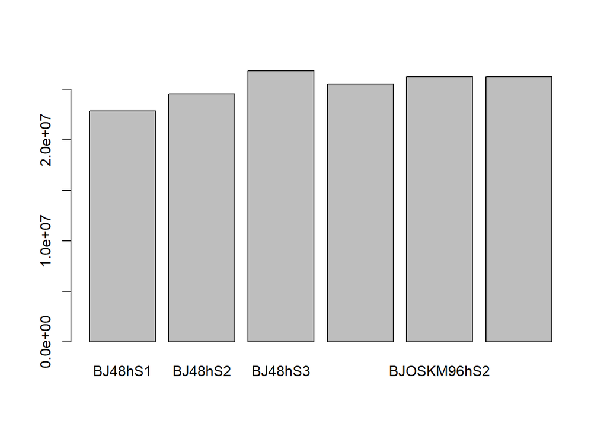

```r
colSums(counts(dds_yamanaka)) %>% barplot
```

```r
dim(dds_yamanaka)
```

```
## [1] 63241     6
```

```r
keep_genes <- rowSums(counts(dds_yamanaka)) > 0
dds_yamanaka <- dds_yamanaka[keep_genes, ]
dim(dds_yamanaka)
```

```
## [1] 37480     6
```

```r
conditions <- factor(c("Control", "Control", "Control",
                       "96 Hours Post-OSKM", "96 Hours Post-OSKM", "96 Hours Post-OSKM"))

# Update colData with the correct conditions
colData(dds_yamanaka)$condition <- conditions

levels(dds_yamanaka$condition)
```

```
## [1] "96 Hours Post-OSKM" "Control"
```

```r
dds_yamanaka <- estimateSizeFactors(dds_yamanaka) #calculate size factors and add them to the object.
```

```
##   Note: levels of factors in the design contain characters other than
##   letters, numbers, '_' and '.'. It is recommended (but not required) to use
##   only letters, numbers, and delimiters '_' or '.', as these are safe characters
##   for column names in R. [This is a message, not a warning or an error]
```

```r
dds_yamanaka <- estimateDispersions(dds_yamanaka)
```

```
##   Note: levels of factors in the design contain characters other than
##   letters, numbers, '_' and '.'. It is recommended (but not required) to use
##   only letters, numbers, and delimiters '_' or '.', as these are safe characters
##   for column names in R. [This is a message, not a warning or an error]
```

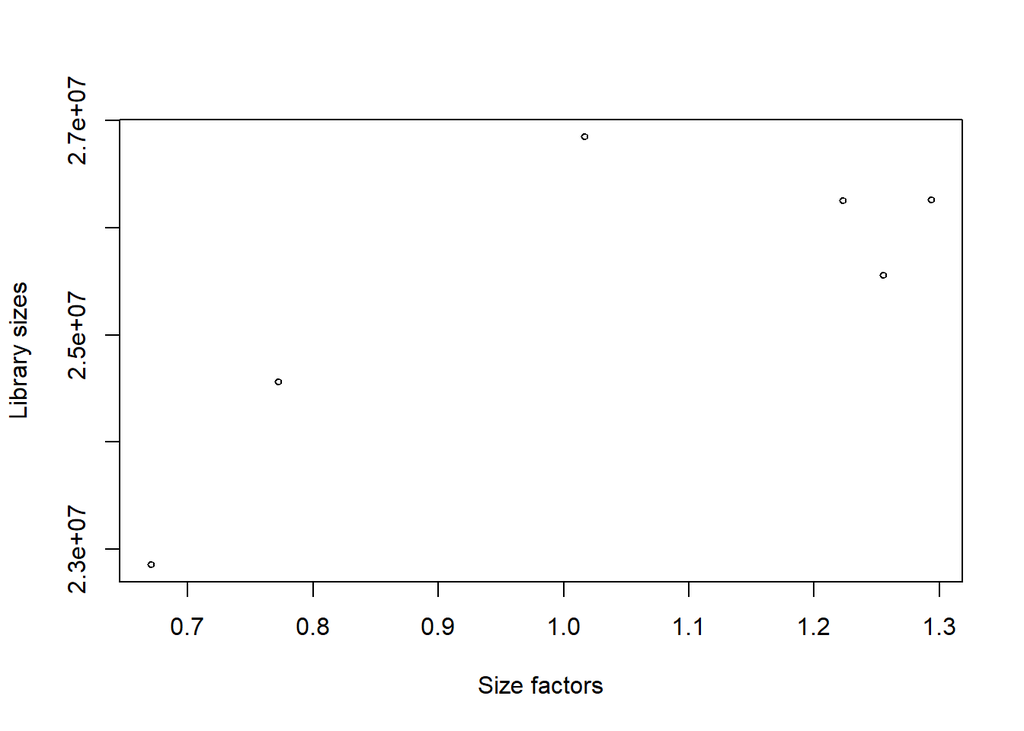

```r
dds_yamanaka = nbinomWaldTest(dds_yamanaka)
plot( sizeFactors(dds_yamanaka), colSums(counts(dds_yamanaka)),
ylab = "Library sizes", xlab = "Size factors", cex = .6 )
```

```r
dds_yamanaka
```

```
## class: DESeqDataSet
## dim: 37480 6
## metadata(1): version
## assays(4): counts mu H cooks
## rownames(37480): ENSG00000290825.1 ENSG00000227232.6 ...
##   ENSG00000278817.1 ENSG00000277196.4
## rowData names(28): Geneid Chr ... deviance maxCooks
## colnames(6): BJ48hS1 BJ48hS2 ... BJOSKM96hS2 BJOSKM96hS3
## colData names(2): condition sizeFactor
```

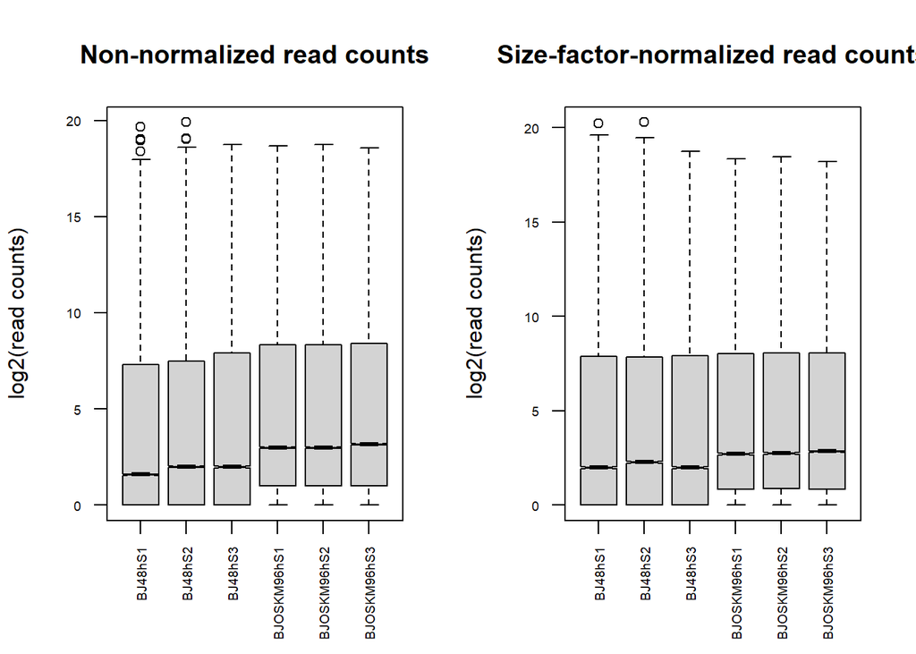

```r
# Set up the plotting area to accommodate two plots side by side
par(mfrow=c(1,2))

# Extract sample names from the DESeq2 object
sample_names <- colnames(counts(dds_yamanaka))

# Box plot of non-normalized counts
boxplot(log2(counts(dds_yamanaka) + 1), notch=TRUE,
        main="Non-normalized read counts",
        ylab="log2(read counts)",
        names=sample_names, # Add sample names as x-axis labels
        cex.axis=0.6, # Adjust size of axis labels if necessary
        las=2) # Rotate x-axis labels to make them vertical

# Box plot of size-factor normalized values
boxplot(log2(counts(dds_yamanaka, normalized=TRUE) + 1), notch=TRUE,
        main="Size-factor-normalized read counts",
        ylab="log2(read counts)",
        names=sample_names, # Add sample names as x-axis labels
        cex.axis=0.6, # Adjust size of axis labels if necessary
        las=2) # Rotate x-axis labels to make them vertical
```

The difference post-normalization does not appear extremely significant, but it does help bring the mean log-transformed read counts of the two conditions closer to one another.

For ease of access, I produce a log-transformed counts matrix and a log-transformed normalized counts matrix that I will include within my assays of my greater DESeq2 object.

```r
assay(dds_yamanaka, "log_counts") <- log2(counts(dds_yamanaka, normalized = FALSE) + 1)
#Log-normalized read counts
assay(dds_yamanaka, "log_norm_counts") <- log2(counts(dds_yamanaka, normalized=TRUE) + 1)
```

Within each condition amongst the technical replicates, I’ll now make a scatterplot of my log normalized counts against one another to ensure that the samples’ gene values highly correlate.

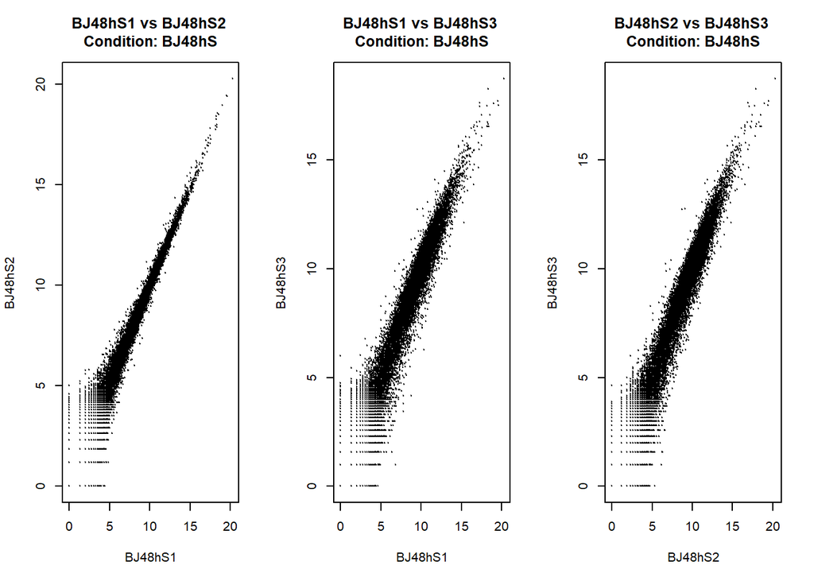

```r
# Load necessary libraries
library(DESeq2)
library(dplyr)
library(ggplot2)

# Assuming 'dds_yamanaka' is already your DESeq2 object and log_norm_counts are already calculated
sample_names <- colnames(dds_yamanaka)

# Define groups based on conditions
condition1 <- grep("BJ48hS", sample_names, value = TRUE)
condition2 <- grep("BJOSKM96hS", sample_names, value = TRUE)

# Function to plot each condition's sample pairs
plot_samples <- function(samples, condition_label) {
  if (length(samples) < 2) {
    cat(sprintf("Not enough samples to plot for condition %s\n", condition_label))
    return()  # Skip plotting if less than two samples
  }

  # Setup the plotting area
  par(mfrow = c(1, choose(length(samples), 2)))

  # Generate combinations and plot
  combn(samples, 2, function(pair) {
    dds_yamanaka[, pair] %>%
      assay("log_norm_counts") %>%
      { plot(x = .[,1], y = .[,2], xlab = pair[1], ylab = pair[2], pch = 20, cex = .1,
             main = paste(pair[1], "vs", pair[2], "\nCondition:", condition_label)) }
  }, simplify = FALSE)
}

# Perform the plotting for each condition
plot_samples(condition1, "BJ48hS")
```

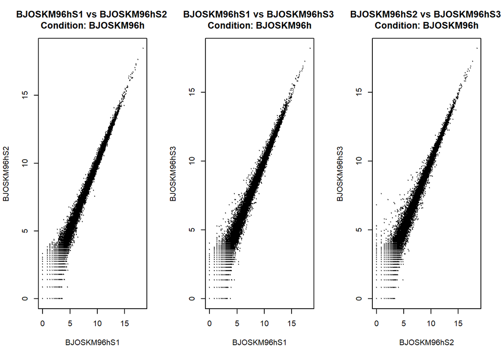

```r
plot_samples(condition2, "BJOSKM96h")
```

From the fanning out in the bottom left corner of all of the sample plots, we are seeing the standard behavior of expression level standard deviation depending upon the mean, where genes with low read counts exhibit high variance.

I use VST to help mitigate our heteroskedasticity. I know that rlog was recommended in class as being better optimized for RNA-seq read counts, but it was repeatedly crashing my R session (this is presumably due to my high read count samples). Reading up on the documentation, the “blind” parameter should be set to false if you expected large transcriptional differences between your conditions. Could you guys give me some feedback on this one? The Yamanaka factors (as you’ll see in my PCA below) are fairly transcriptionally transformative, but I don’t know what exactly qualifies as “large.”

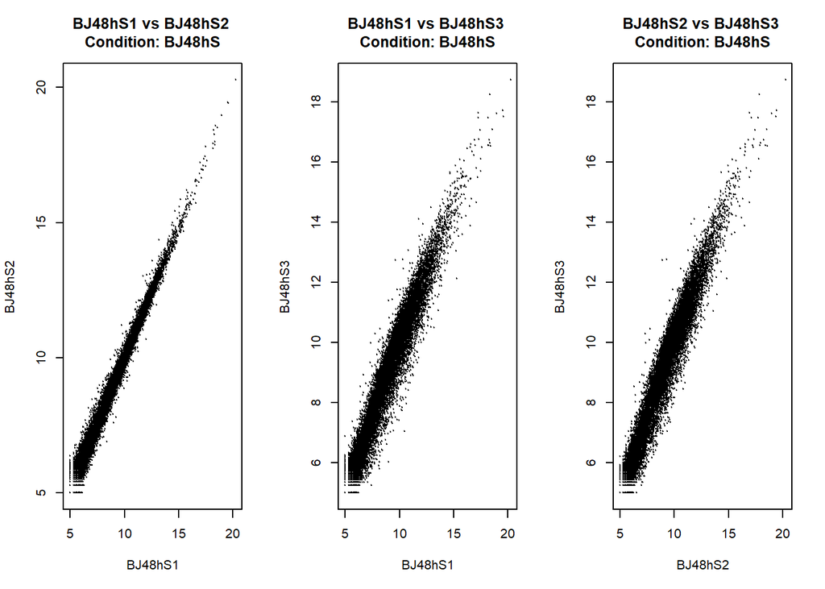

```r
# Load necessary library
library(DESeq2)

# Compute the Variance Stabilizing Transformation (VST)
vst_dds <- vst(dds_yamanaka, blind = FALSE)

# Define groups based on conditions
sample_names <- colnames(vst_dds)
condition1 <- grep("BJ48hS", sample_names, value = TRUE)
condition2 <- grep("BJOSKM96hS", sample_names, value = TRUE)

# Function to plot each condition's sample pairs
vst_plot_samples <- function(samples, condition_label) {
  if (length(samples) < 2) {
    cat(sprintf("Not enough samples to plot for condition %s\n", condition_label))
    return()  # Skip plotting if less than two samples
  }

  # Setup the plotting area
  par(mfrow = c(1, choose(length(samples), 2)))

  # Generate combinations and plot
  combn(samples, 2, function(pair) {
    data_matrix <- assay(vst_dds[, pair])
    plot(x = data_matrix[,1], y = data_matrix[,2], xlab = pair[1], ylab = pair[2], pch = 20, cex = 0.1,
         main = paste(pair[1], "vs", pair[2], "\nCondition:", condition_label))
  }, simplify = FALSE)
}

# Perform the plotting for each condition
vst_plot_samples(condition1, "BJ48hS")
```

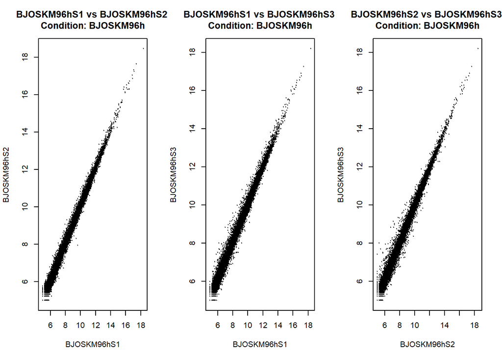

```r
vst_plot_samples(condition2, "BJOSKM96h")
```

VST tightens up the variance significantly at lower expression levels, but not quite so much as rlog did in some of the in-class examples. We see more overall variability amongst the pre-OSKM BJ48h samples.

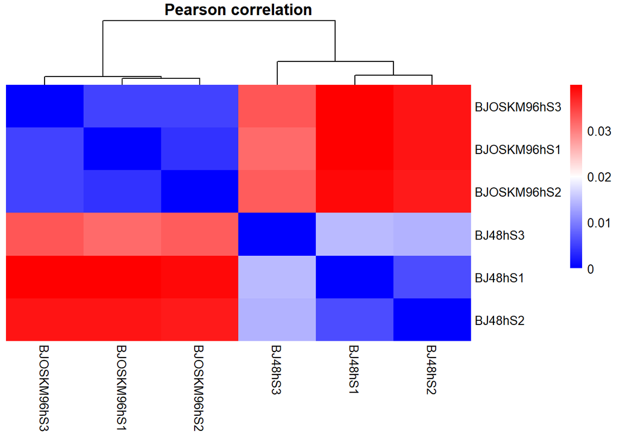

```r
# Load necessary libraries
library(DESeq2)
library(pheatmap)
# Assuming 'vst_dds' is your DESeq2 object with VST data already computed
# First, get the VST data as a matrix
vst_matrix <- assay(vst_dds)

# Calculate Pearson correlation coefficient matrix
corr_coeff <- cor(vst_matrix, method = "pearson")

# Ensure the row and column names of the correlation matrix are set to sample names
rownames(corr_coeff) <- colnames(vst_dds)
colnames(corr_coeff) <- colnames(vst_dds)

# Convert correlation coefficients to a distance matrix
distance_matrix <- as.dist(1 - corr_coeff)

# Create a heatmap using pheatmap
pheatmap::pheatmap(distance_matrix,
                   main = "Pearson correlation",
                   color = colorRampPalette(c("blue", "white", "red"))(255),  # Color gradient from blue to red
                   clustering_distance_rows = distance_matrix,
                   clustering_distance_cols = distance_matrix,
                   labels_row = rownames(corr_coeff),
                   labels_col = colnames(corr_coeff),
                   treeheight_row = 0,
                   show_rownames = TRUE,
                   show_colnames = TRUE,
                   fontsize_row = 10,
                   fontsize_col = 10,
                   border_color = NA)  # No border between cells
```

```r
rv <- rowVars(vst_matrix)
top_variable <- order(rv, decreasing = TRUE)[seq_len(500)]
pca <- prcomp(t(vst_matrix[top_variable, ]))
head(pca$x)
```

```
##                   PC1        PC2         PC3        PC4         PC5
## BJ48hS1     -36.21924   6.957445 -0.21053436 -2.0311789  2.78977337
## BJ48hS2     -35.48903   4.477675  0.04557231  1.8692401 -3.42375872
## BJ48hS3     -30.94076 -12.265437  0.07467327  0.3267149  0.70588550
## BJOSKM96hS1  33.43721  -1.209754 -3.05521133 -3.5531901 -1.70377329
## BJOSKM96hS2  35.77897   1.553687 -2.85706333  3.5816557  1.61520896
## BJOSKM96hS3  33.43286   0.486384  6.00256344 -0.1932416  0.01666418
##                       PC6
## BJ48hS1      2.465216e-14
## BJ48hS2     -1.413279e-14
## BJ48hS3     -3.006276e-15
## BJOSKM96hS1  1.596466e-14
## BJOSKM96hS2  5.169476e-15
## BJOSKM96hS3  3.495468e-15
```

```
## using ntop=500 top features by variance
```

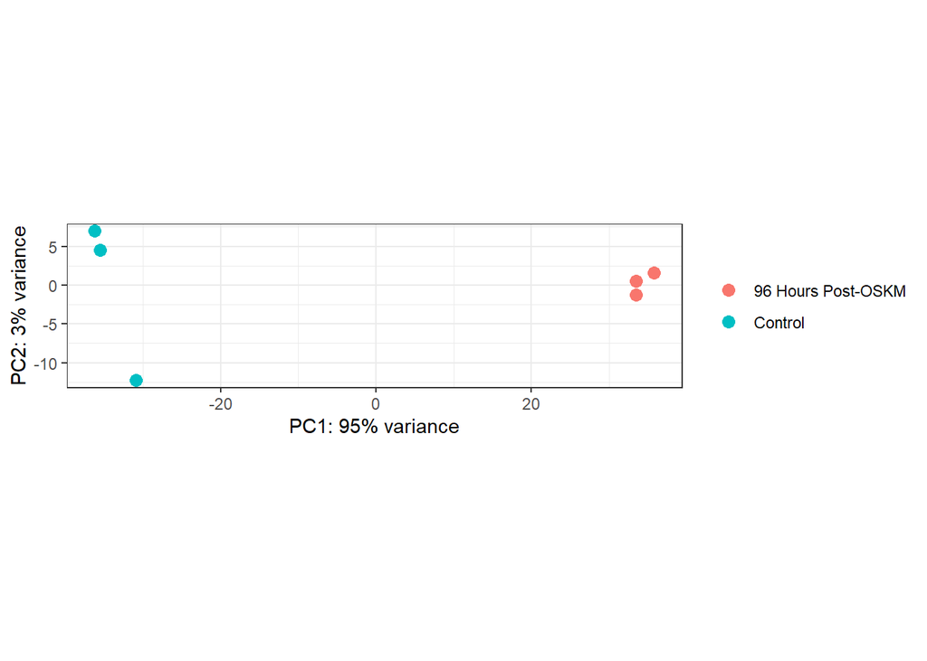

```r
plotPCA(vst_dds) +
labs(color=NULL) +
theme_bw()
```

```r
# Load necessary libraries
library(DESeq2)
library(tidyverse)
# Read the transcription factor list CSV (update path as necessary)
tf_list <- read.csv("Human Transcription Factor List.csv")

# Filter for confirmed transcription factors
confirmed_tfs <- tf_list %>%
  filter(`Is.TF.` == "Yes") %>%
  pull(`Ensembl.ID`)

print(length(confirmed_tfs))
```

```
## [1] 1639
```

```r
colData(dds_yamanaka)
```

```
## DataFrame with 6 rows and 2 columns
##                      condition sizeFactor
##                       <factor>  <numeric>
## BJ48hS1     Control              0.670553
## BJ48hS2     Control              0.772190
## BJ48hS3     Control              1.016449
## BJOSKM96hS1 96 Hours Post-OSKM   1.254946
## BJOSKM96hS2 96 Hours Post-OSKM   1.222564
## BJOSKM96hS3 96 Hours Post-OSKM   1.293338
```

I have two options. I can transfer sizeFactors, and thus normalize my gene counts, as calculated for the whole gene set to my TF subset. Testing, then, will effectively ask about changes of Transcription Factors relative to the overall transcriptome. Or, I can recompute size factors for my TF subset, and normalize to just the size of the human TF dataset. My testing, then, will more ask question about compositional changes among purely Transcription Factors themselves.

For a variety of reasons, like TFs short half lives, bursty expression, and non-ubiquity expression, this TF-only normalization could invite a fair bit of noise. Additionally DESeq2’s outlier-handling is not necessarily built to handle the possibility of a small number of TFs being expressed very highly, and this could make everything else look downregulated in comparison. But, for both educational purposes and my own curiosity, I will do a short exploratory analysis of the effects of normalizing to the TF subset, specifically. This involves subsetting from my total-gene-set DESeq2 object, and then recomputing size factors and getting results from this new DESeq2 object.

```r
# Remove version numbers from the rownames of dds_yamanaka
rownames(dds_yamanaka) <- gsub("\\..*", "", rownames(dds_yamanaka))

# Filter dds_yamanaka for TFs
tf_dds <- dds_yamanaka[rownames(dds_yamanaka) %in% confirmed_tfs, ]

tf_dds
```

```
## class: DESeqDataSet
## dim: 1549 6
## metadata(1): version
## assays(6): counts mu ... log_counts log_norm_counts
## rownames(1549): ENSG00000188290 ENSG00000157933 ... ENSG00000184895
##   ENSG00000067646
## rowData names(28): Geneid Chr ... deviance maxCooks
## colnames(6): BJ48hS1 BJ48hS2 ... BJOSKM96hS2 BJOSKM96hS3
## colData names(2): condition sizeFactor
```

90 of the transcription factors from the Lambert human TF list do not manifest in my TF DESeq2 object, presumably due to my having filtered out zero count genes (for both conditions) earlier. So I will be evaluating differential expression for 1549 transcription factors.

```r
# Check if tf_dds has any transcription factors
if (nrow(tf_dds) == 0) {
    stop("No matching transcription factors found.")
} else {

    # Compute the Variance Stabilizing Transformation (VST)
    vst_tf <- vst(tf_dds, blind = FALSE)
    assay(tf_dds, "vst") <- assay(vst_tf)
}
```

```
## using ntop=500 top features by variance
```

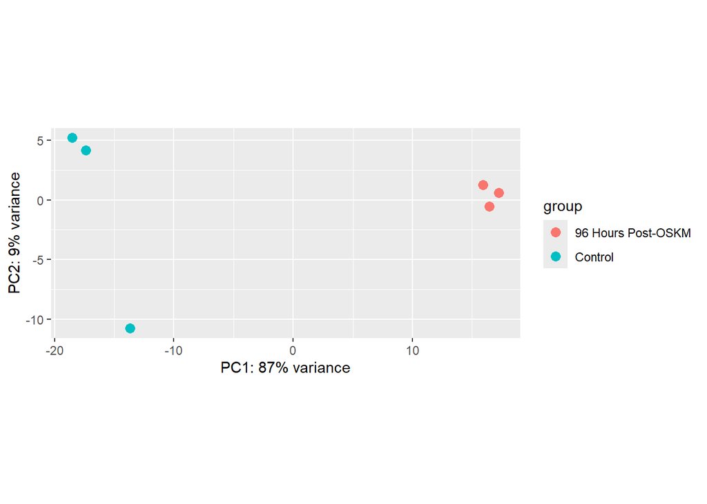

```r
plotPCA(vst(tf_dds))
```

This plot, besides the ultimate hubris of not subsetting directly from a results object of dds_yamanaka, is useful. Knowing how much TFs contribute to overall expression can give us a sense of whether or not focusing exclusively on them would require specialized processing, and hwo much expression stability can be expected from them.

```r
# Calculate total counts per sample in the original dataset
total_counts_all_genes <- colSums(counts(dds_yamanaka))

# Calculate total counts per sample for just transcription factors
total_counts_tfs <- colSums(counts(tf_dds))

# Calculate the fraction of counts from TFs
fraction_tfs <- total_counts_tfs / total_counts_all_genes

# Print the fraction of counts from TFs
print(fraction_tfs)
```

```
##     BJ48hS1     BJ48hS2     BJ48hS3 BJOSKM96hS1 BJOSKM96hS2 BJOSKM96hS3
##  0.05005134  0.04990567  0.04297827  0.05927973  0.05738511  0.06098927
```

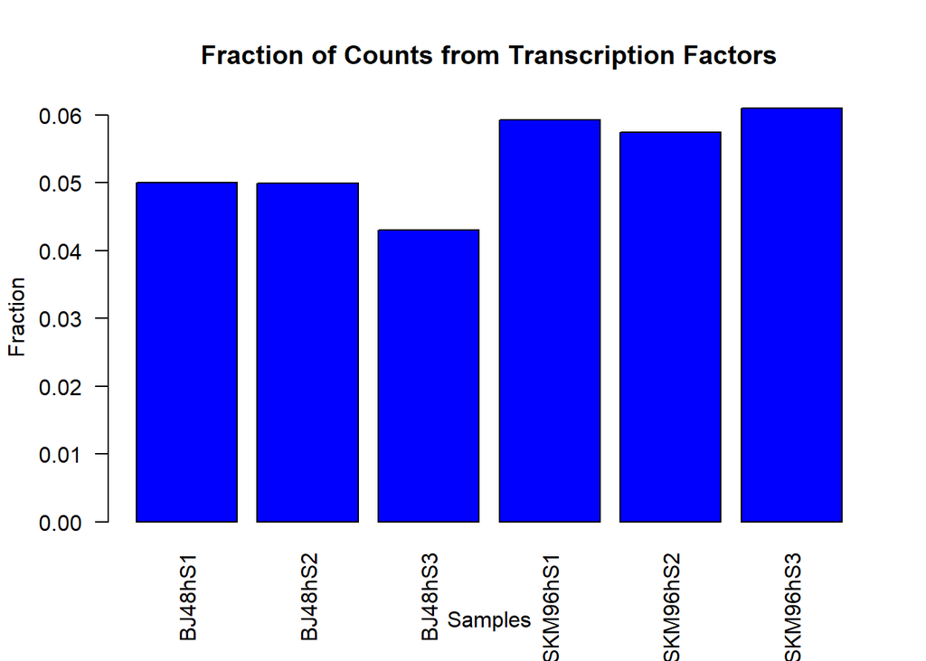

```r
# Create a barplot of the fraction of counts from TFs
barplot(fraction_tfs,
        main = "Fraction of Counts from Transcription Factors",
        ylab = "Fraction",
        xlab = "Samples",
        col = "blue",
        las = 2)  # Adjust label orientation if necessary
```

Following Merv’s advice from Piazza, I want to evaluate how my size factors change from the original ones for the entire gene set, versus recomputed ones for just my 1,549 human transcription factors.

```r
sizeFactors(dds_yamanaka)
```

```
##     BJ48hS1     BJ48hS2     BJ48hS3 BJOSKM96hS1 BJOSKM96hS2 BJOSKM96hS3
##   0.6705534   0.7721904   1.0164485   1.2549459   1.2225639   1.2933379
```

```r
sizeFactors(tf_dds)
```

```
##     BJ48hS1     BJ48hS2     BJ48hS3 BJOSKM96hS1 BJOSKM96hS2 BJOSKM96hS3
##   0.6705534   0.7721904   1.0164485   1.2549459   1.2225639   1.2933379
```

```r
# Create a copy of the original DESeq2 object
tf_dds_copy <- tf_dds

# Recalculate size factors for just the transcription factors
tf_dds_copy <- estimateSizeFactors(tf_dds_copy)
```

```
##   Note: levels of factors in the design contain characters other than
##   letters, numbers, '_' and '.'. It is recommended (but not required) to use
##   only letters, numbers, and delimiters '_' or '.', as these are safe characters
##   for column names in R. [This is a message, not a warning or an error]
```

```r
sizeFactors(tf_dds_copy)
```

```
##     BJ48hS1     BJ48hS2     BJ48hS3 BJOSKM96hS1 BJOSKM96hS2 BJOSKM96hS3
##   0.6275458   0.7373130   0.9251530   1.3171609   1.2857707   1.4402985
```

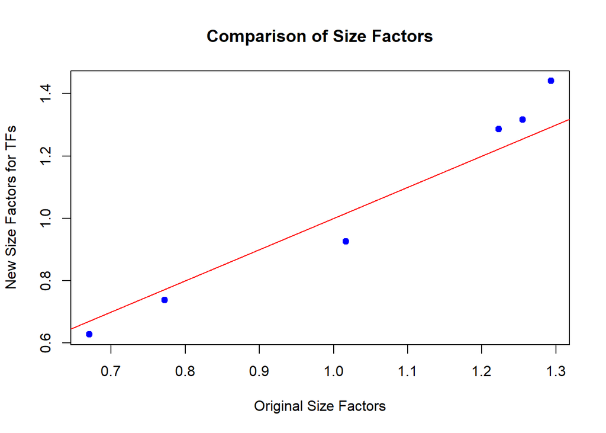

```r
# Extract size factors
original_size_factors <- sizeFactors(tf_dds)
new_size_factors <- sizeFactors(tf_dds_copy)

# Create a plot for comparison
plot(original_size_factors, new_size_factors,
     xlab = "Original Size Factors",
     ylab = "New Size Factors for TFs",
     main = "Comparison of Size Factors",
     pch = 19, col = "blue")
abline(0, 1, col = "red")  # Add a y=x line to aid in visual comparison
```

The $x = y$ line here represents where points would fall if we observed no size factor change. The first three (reading from left to right) dots represent my pre-Yamanaka samples, and the last three represent my post-Yamanaka samples. The pre-yamanaka size factors decrease, as compared to the original, and the post-ones increase.

My concern is that a small number of TFs, expressed highly enough, could make everything else look down-regulated unfairly. So I use Cook’s distance, which measures the influence of each TF gene on the computed size factors, to see if I have any serious outliers shifting the balance of my normalization.

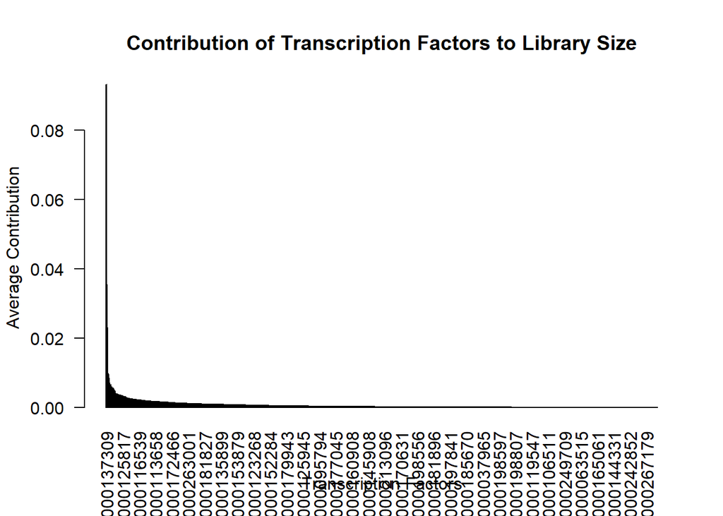

```r
# Calculate contributions of each gene to total counts
total_counts_per_sample <- colSums(counts(tf_dds))
gene_contributions <- sweep(counts(tf_dds), 2, total_counts_per_sample, "/")
average_contributions <- rowMeans(gene_contributions)

# Plot these contributions to identify potential outliers
barplot(sort(average_contributions, decreasing = TRUE),
        main = "Contribution of Transcription Factors to Library Size",
        xlab = "Transcription Factors", ylab = "Average Contribution",
        las = 2, col = "blue")
```

```r
# Calculate Cook's distances for each gene
dds_fit <- DESeq(tf_dds_copy, fitType="mean")
```

```
## found already estimated dispersions, replacing these
```

```
##   Note: levels of factors in the design contain characters other than
##   letters, numbers, '_' and '.'. It is recommended (but not required) to use
##   only letters, numbers, and delimiters '_' or '.', as these are safe characters
##   for column names in R. [This is a message, not a warning or an error]
```

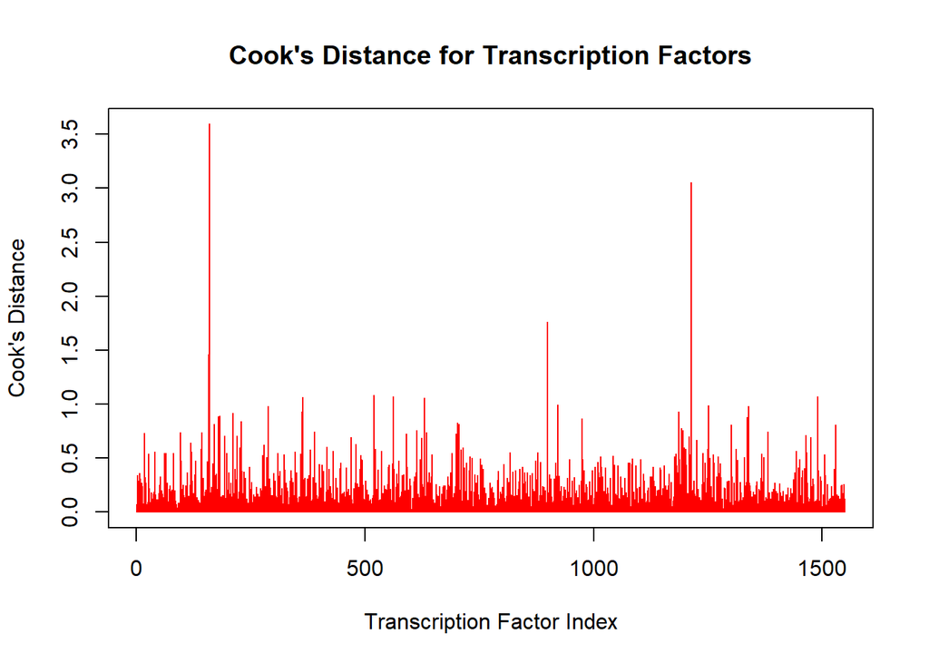

```r
cooks_distances <- assays(dds_fit)[["cooks"]]
mean_cooks <- rowMeans(cooks_distances, na.rm = TRUE)

# Plot Cook's distances to identify highly influential genes
plot(mean_cooks, type='h',
     main="Cook's Distance for Transcription Factors",
     xlab="Transcription Factor Index", ylab="Cook's Distance",
     col="red")
```

Purely visually, we can see that two to three different transcription factor genes have vastly higher Cook’s Distance scores than the rest.

```r
# Determine the 99th percentile threshold for Cook's distance
threshold_cooks <- quantile(mean_cooks, 0.99)

# Identify TFs whose Cook's distance exceeds the 95th percentile
high_influence_tfs <- names(mean_cooks)[mean_cooks > threshold_cooks]

# Report Cook's distances for these TFs
high_influence_cooks <- mean_cooks[high_influence_tfs]

# Create a named vector to display results more clearly
results <- setNames(high_influence_cooks, high_influence_tfs)

# Print the results
print(results)
```

```
## ENSG00000152284 ENSG00000168874 ENSG00000079263 ENSG00000250312 ENSG00000113196
##       1.4587939       3.5951188       0.9162087       0.9801568       0.9310597
## ENSG00000039600 ENSG00000128573 ENSG00000185697 ENSG00000165244 ENSG00000170345
##       1.0654001       1.0865443       1.0696070       1.0585645       1.7643680
## ENSG00000188779 ENSG00000197124 ENSG00000198597 ENSG00000188227 ENSG00000213793
##       0.9931610       0.9272831       3.0527208       0.9898413       0.9782261
## ENSG00000160224
##       1.0727197
```

Setting a 99th percentile cutoff, we see that, even among the top 1th percentile of influential TF genes, we are seeing one TF (ENSG00000168874/ATOH8), that contributes almost 4 times more to size factor calculation than the bottom of this quantile.